# Introduction to deep networks (keras)

### What do we need

```r
  library(magrittr)
  library(keras)
```

Installing keras requires

- **Python** (2 for CPU, 3 for GPU).
- A virtual environment (virtualenv, anaconda)
- Tensorflow is the default option

```r
install_keras(tensorflow = "default")
```

- Recommended R package: `magrittr`

### A MNIST example

- The MNIST database is a large database of handwritten digits that is commonly used for training various image processing systems.
- Handwritten digits are stored as squared matrices of size 28 by 28 (784) pixels. Each pixel has 256 values.

```r
  mnist <- dataset_mnist()
  x_train <- mnist$train$x
  y_train <- mnist$train$y
  x_test <- mnist$test$x
  y_test <- mnist$test$y
```

- **Question:** Discriminate digit 7 ($y = 1$) from digit 2 ($y = 0$)

```r
# extract digits 2 and 7 from MNIST and build some training data
  boo_train <- y_train == 2 | y_train == 7
  x_train <- mnist$train$x[boo_train,,]
  y_train <- mnist$train$y[boo_train]

# same for test data
  boo_test <- y_test == 2 | y_test == 7
  x_test <- mnist$test$x[boo_test,,]
  y_test <- mnist$test$y[boo_test]
```

- Most “7” images look like this one (Note that french people write them differently).

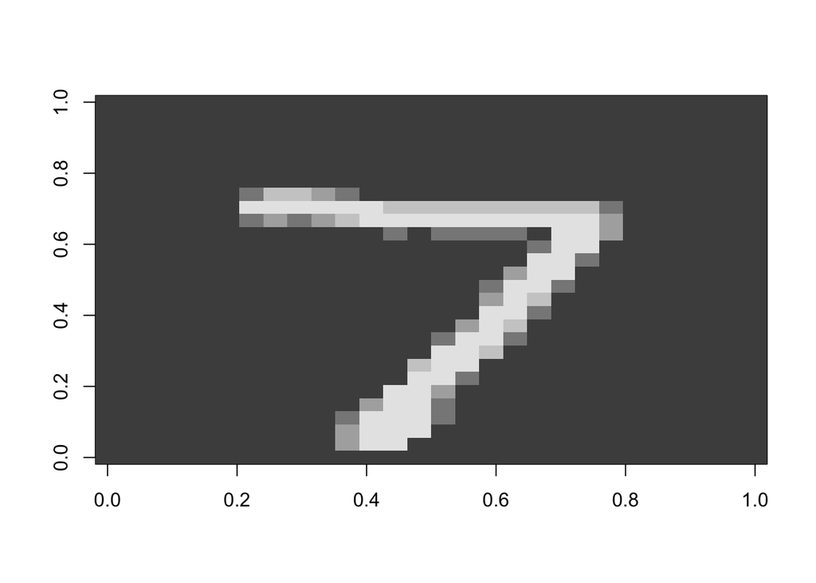

```r
  image(t(x_test[1, 28:1,]), col = grey.colors(5))
```

- We need to flatten the images (= convert them as vectors) and to rescale their values

```r
# Flattening
x_train <- array_reshape(x_train,
                         c(nrow(x_train),
                         784))
x_test <- array_reshape(x_test,
                        c(nrow(x_test),
                        784))

# Rescaling
x_train <- x_train/255
x_test <- x_test/255
```

- Convert the labels {2,7} into binary values

```r
  y_train <- as.numeric(y_train == 7)
  y_test <-  as.numeric(y_test == 7)
```

### Building models with keras

- It is based on functional programming. Consider a single hidden layer with 128 neurons. Half of the units are dropped out during an epoch.

```r
model <- keras_model_sequential()
model %>%
    layer_dense(units = 128,
                activation = 'relu',
                input_shape = 784) %>%
    layer_dropout(rate = 0.5) %>%
    layer_dense(units = 1,
                activation = 'sigmoid')
```

- Compiling models with keras. We need to specify a loss function and a minimization method

```r
model %>% compile(
    loss = 'binary_crossentropy',
    optimizer = optimizer_sgd(lr = 0.01,
                              decay = 0.001),
    metrics = c('accuracy')
)
```

- Fitting our neural network model

```r
set.seed(110101011)
history <- model %>%
           fit(x_train,
               y_train,
               epochs = 20,
               batch_size = 100,
               validation_data = list(x_test, y_test),
               verbose = 0
            )
```

### Evaluating the results

- Log-loss and accuracy

```r
model %>% evaluate(x_test, y_test)
```

```
## $loss
## [1] 0.08389094
##
## $acc
## [1] 0.9742718
```

- Confusion matrix

```r
pred_class <- model %>%
              predict_classes(x_test)

table(predicted = pred_class,
      observed = mnist$test$y[boo_test])
```

```
##          observed
## predicted    2    7
##         0 1015   36
##         1   17  992
```

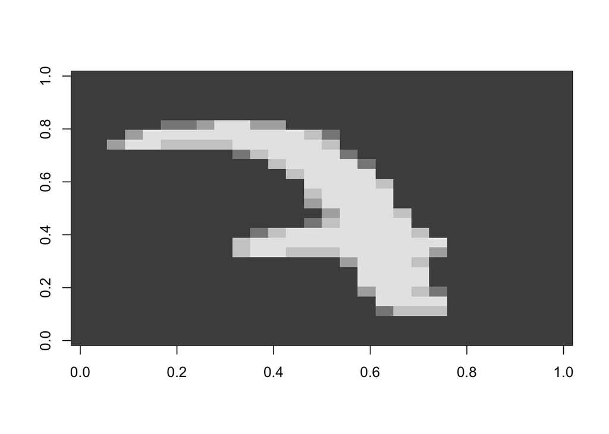

```r
false_positive <- which(mnist$test$y[boo_test] == 7 & pred_class[,1] == 0)
x_test[false_positive[1],] %>% matrix(nrow = 28) %>% .[,28:1] %>% image(col = grey.colors(5))
```

### For fun: using pretrained models

- Using pretrained model is one of the most common applications of DL.

```r
pretrained_model = application_resnet50(weights = 'imagenet')
```

```r
img <- mnist$test$x[false_positive[3],,]

x <- array(NA, c(1,28,28,3))
x[1, , ,1:3] <- img
x <- image_array_resize(x, 224, 224)
x <- imagenet_preprocess_input(x)
```

And see it’s prediction in Imagenet (yes, that’s n’imp)

```r
pred <- pretrained_model %>% predict(x)
imagenet_decode_predictions(pred, top = 4)[[1]]
```

| class_name | class_description | score |
| --- | --- | --- |
| n04228054 | ski | 0.33216310 |
| n03929660 | pick | 0.13949098 |
| n03109150 | corkscrew | 0.12036014 |
| n01930112 | nematode | 0.09367518 |